# Analysis of Total Reading Times

Henrik Singmann

13 Oktober, 2017

```r
require(dplyr)
require(tidyr)
require(stringr)
require(ggplot2)
require(afex)
require(lattice) # for qqmath
require(gridExtra)
library(ggthemes)
theme_set(theme_light())
```

# Data Preparation

```r
data_in <- read.csv("TTs_plus_ratings.csv")
data_in$P.s <- factor(data_in$P.s)
data_in$Item <- factor(data_in$Item)
drp_r <- droplevels(data_in[data_in$Item != "9" ,])
nas <- is.na(drp_r$spillover) | is.na(drp_r$Consequent)
drp_r <- droplevels(drp_r[!nas,])
```

For the analysis we remove 2 trials with missing data in either spillover or Consequent. Then we transform all RTs from ms to s and calculate transformed versions using either `log` or the inverse transformation. We also z-transform the continuous `Accepts` variable.

```r
drp_r <- drp_r %>%
  mutate(
    antecedent = Antecedent/1000,
    log_ant = log(antecedent),
    inv_ant = 1/antecedent,
    consequent = Consequent/1000,
    log_con = log(consequent),
    inv_con = 1/consequent,
    spillover = spillover/1000,
    log_spill = log(spillover),
    inv_spill = 1/spillover,
    acc_z = (Accepts - mean(Accepts))/sd(Accepts),
    #conf_z = (Confident- mean(Confident))/sd(Confident),
    log_acc= log(Accepts))
```

We then plot the three versions of the DVs.

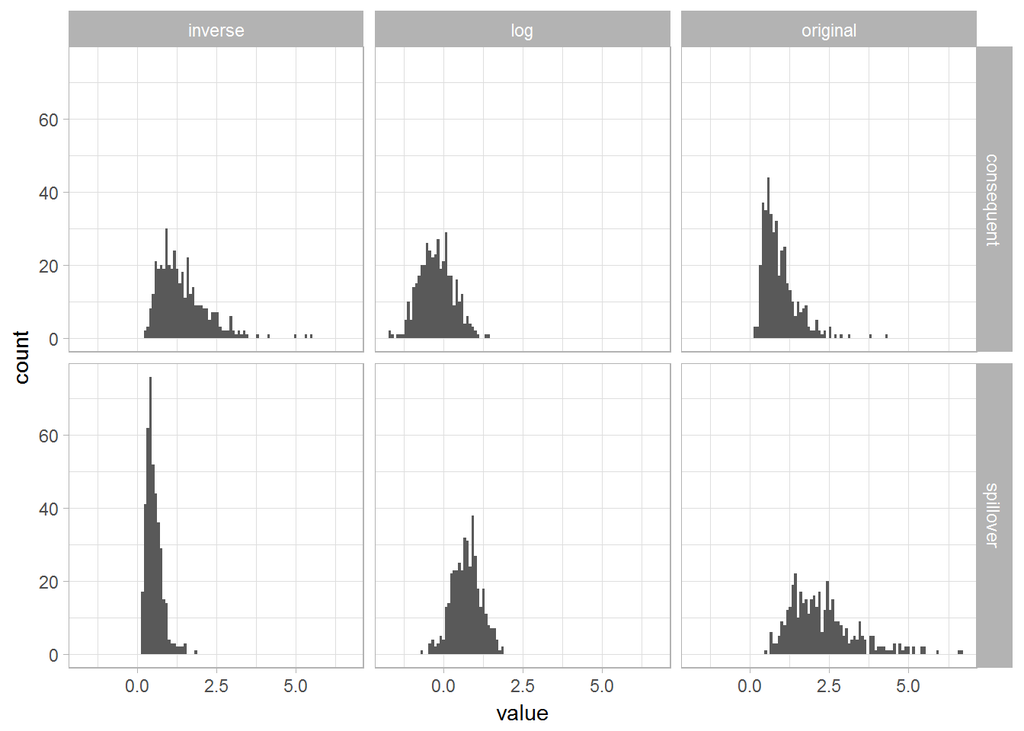

```r
dplot <- drp_r %>%
  gather("key", "value",consequent:inv_spill, spillover) %>%
  mutate(region = if_else(str_detect(key, "spill"), "spillover", "consequent"),
         type = if_else(str_detect(key, "^log"), "log",
                        if_else(str_detect(key, "^inv"), "inverse", "original")))

ggplot(data = dplot) +
  geom_histogram(mapping = aes(x = value), bins = 100) +
  facet_grid(region ~ type)
```

As can be seen, the log transformation helps quite a bit in achieving approximate normality for both consequent and spillover. However, both DVs seems to have too fat tails. For the `spillover` variable the untransformed DV may work better. For the untransformed values there are quite a few DVs above 5 seconds (consequent = 0, spillover = 0.02), above 3 seconds (consequent = 0.01, spillover = 0.2) or above 2.5 seconds (consequent = 0.02, spillover = 0.34).

# Descriptive Plots

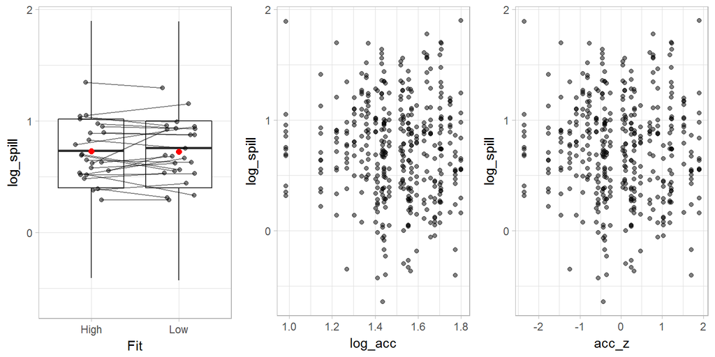

```r
drd_a2 <- drp_r %>%
  group_by(P.s, Fit) %>%
  summarise(log_spill = mean(log_spill))

drp_r$Fit2 <- jitter(as.numeric(drp_r$Fit))
drd_a2$Fit2 <- jitter(as.numeric(drd_a2$Fit))

pres_rp_a <- ggplot(data = drp_r, mapping = aes(x = Fit, y = log_spill)) +
  geom_boxplot(outlier.color =  NA) +
  geom_line(data = drd_a2, aes(x=Fit2, y=log_spill, group = P.s), alpha = 0.5) +
  geom_point(data = drd_a2, aes(x=Fit2, y=log_spill, group = P.s), alpha = 0.5) +
  stat_summary(fun.y = "mean", colour = "red", size = 2, geom = "point")

pres_rp_b <- ggplot(data = drp_r, mapping = aes(x = log_acc, y = log_spill)) +
  geom_point(alpha = 0.5)

pres_rp_c <- ggplot(data = drp_r, mapping = aes(x = acc_z, y = log_spill)) +
  geom_point(alpha = 0.5)

grid.arrange(pres_rp_a, pres_rp_b, pres_rp_c, ncol = 3)
```

# Consequent

Note that the maximal model for models including `Fit` have random slopes for `Fit` for both random effects grouping factors (i.e., participant `P.s` and `Item`). For models including the continuous fit measure `Accepts` we have by-participant random slopes for `Accepts`, but by-item random slopes for `Fit` (as `Accepts` has only two different values for each `Item`, using the binary `Fit` variable seems more reasonable.)

## With Fit (log-transformed RTs)

```r
m_fp_con_1 <- mixed(log_con ~ Fit + (Fit|P.s) + (Fit| Item), drp_r, progress = FALSE)
```

```
## Contrasts set to contr.sum for the following variables: Fit, P.s, Item
```

```r
summary(m_fp_con_1)
```

```
## Linear mixed model fit by REML ['merModLmerTest']
## Formula: log_con ~ Fit + (Fit | P.s) + (Fit | Item)
##    Data: drp_r
##
## REML criterion at convergence: 490.3
##
## Scaled residuals:
##     Min      1Q  Median      3Q     Max
## -2.7240 -0.5898 -0.0262  0.5508  3.9727
##
## Random effects:
##  Groups   Name        Variance  Std.Dev. Corr
##  P.s      (Intercept) 0.0710497 0.26655
##           Fit1        0.0025638 0.05063  0.90
##  Item     (Intercept) 0.0615658 0.24812
##           Fit1        0.0009968 0.03157  0.64
##  Residual             0.1526958 0.39076
## Number of obs: 406, groups:  P.s, 24; Item, 17
##
## Fixed effects:
##             Estimate Std. Error t value
## (Intercept) -0.21464    0.08342  -2.573
## Fit1        -0.04071    0.02330  -1.747
##
## Correlation of Fixed Effects:
##      (Intr)
## Fit1 0.413
```

Although the correlations are not extreme, we try by removing them.

```r
m_fp_con_2 <- mixed(log_con ~ Fit + (Fit||P.s) + (Fit|| Item), drp_r, expand_re = TRUE, progress = FALSE)
```

```
## Contrasts set to contr.sum for the following variables: Fit, P.s, Item
```

```r
summary(m_fp_con_2)
```

```
## Linear mixed model fit by REML ['merModLmerTest']
## Formula:
## log_con ~ Fit + ((1 | P.s) + (0 + re1.Fit1 | P.s)) + ((1 | Item) +
##     (0 + re2.Fit1 | Item))
##    Data: drp_r
##
## REML criterion at convergence: 495
##
## Scaled residuals:
##     Min      1Q  Median      3Q     Max
## -2.7634 -0.6040 -0.0435  0.5574  4.0085
##
## Random effects:
##  Groups   Name        Variance  Std.Dev.
##  P.s      (Intercept) 0.0708167 0.26611
##  P.s.1    re1.Fit1    0.0024137 0.04913
##  Item     (Intercept) 0.0618489 0.24869
##  Item.1   re2.Fit1    0.0009961 0.03156
##  Residual             0.1528138 0.39091
## Number of obs: 406, groups:  P.s, 24; Item, 17
##
## Fixed effects:
##             Estimate Std. Error t value
## (Intercept) -0.21397    0.08346  -2.564
## Fit1        -0.04060    0.02317  -1.752
##
## Correlation of Fixed Effects:
##      (Intr)
## Fit1 0.001
```

This does not seem to be justified when looking at likelihood-ratio tests.

```r
anova(m_fp_con_1, m_fp_con_2)
```

```
## Data: drp_r
## Models:
## m_fp_con_2: log_con ~ Fit + ((1 | P.s) + (0 + re1.Fit1 | P.s)) + ((1 | Item) +
## m_fp_con_2:     (0 + re2.Fit1 | Item))
## m_fp_con_1: log_con ~ Fit + (Fit | P.s) + (Fit | Item)
##            Df    AIC    BIC  logLik deviance  Chisq Chi Df Pr(>Chisq)
## m_fp_con_2  7 508.98 537.02 -247.49   494.98
## m_fp_con_1  9 508.34 544.39 -245.17   490.34 4.6422      2    0.09817 .
## ---
## Signif. codes:  0 '***' 0.001 '**' 0.01 '*' 0.05 '.' 0.1 ' ' 1
```

However, the QQ-plot of both models shows some departure from normality for both short RTs and somewhat long RTs. One RT for participant 10 departs particularly strongly. Significant outliers (i.e., observations with absolute standardized/normalized residuals greater than the .995 quantile of the standard normal distribution) are identified by the number of the participant providing this response.

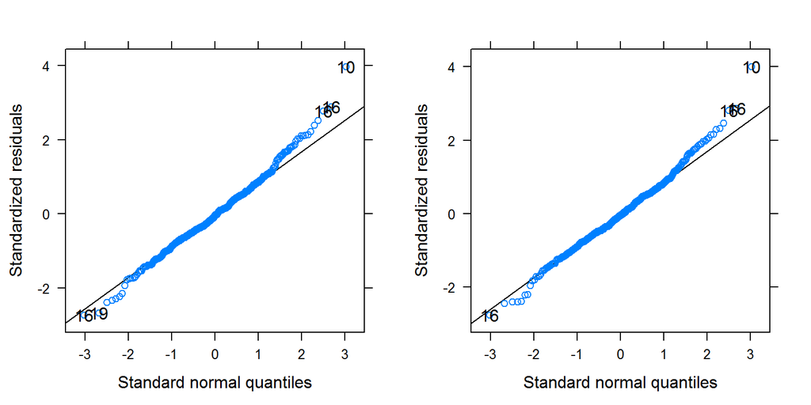

```r
qqp_m1 <- qqmath(m_fp_con_1$full_model, id = 0.01, idLabels = as.character(drp_r$P.s))
qqp_m2 <- qqmath(m_fp_con_2$full_model, id = 0.01, idLabels = as.character(drp_r$P.s))
grid.arrange(qqp_m1, qqp_m2, ncol = 2)
```

The effect of `Fit` is not significant for both models, but approaches significance.

```r
nice(m_fp_con_1)
```

```
## Mixed Model Anova Table (Type 3 tests, KR-method)
##
## Model: log_con ~ Fit + (Fit | P.s) + (Fit | Item)
## Data: drp_r
##   Effect       df    F p.value
## 1    Fit 1, 12.45 3.05     .11
## ---
## Signif. codes:  0 '***' 0.001 '**' 0.01 '*' 0.05 '+' 0.1 ' ' 1
```

```r
nice(m_fp_con_2)
```

```
## Mixed Model Anova Table (Type 3 tests, KR-method)
##
## Model: log_con ~ Fit + (Fit || P.s) + (Fit || Item)
## Data: drp_r
##   Effect       df    F p.value
## 1    Fit 1, 12.27 3.07     .10
## ---
## Signif. codes:  0 '***' 0.001 '**' 0.01 '*' 0.05 '+' 0.1 ' ' 1
```

## With Fit (untransformed RTs)

```r
m_con_u_1 <- mixed(consequent ~ Fit + (Fit|P.s) + (Fit| Item), drp_r, progress = FALSE)
```

```
## Contrasts set to contr.sum for the following variables: Fit, P.s, Item
```

```r
summary(m_con_u_1)
```

```
## Linear mixed model fit by REML ['merModLmerTest']
## Formula: consequent ~ Fit + (Fit | P.s) + (Fit | Item)
##    Data: drp_r
##
## REML criterion at convergence: 550.3
##
## Scaled residuals:
##     Min      1Q  Median      3Q     Max
## -2.0369 -0.5504 -0.1420  0.3693  7.3286
##
## Random effects:
##  Groups   Name        Variance  Std.Dev. Corr
##  P.s      (Intercept) 6.252e-02 0.250045
##           Fit1        1.457e-03 0.038165 1.00
##  Item     (Intercept) 5.808e-02 0.241001
##           Fit1        8.892e-06 0.002982 1.00
##  Residual             1.826e-01 0.427274
## Number of obs: 406, groups:  P.s, 24; Item, 17
##
## Fixed effects:
##             Estimate Std. Error t value
## (Intercept)  0.93225    0.08045  11.589
## Fit1        -0.02479    0.02263  -1.096
##
## Correlation of Fixed Effects:
##      (Intr)
## Fit1 0.243
```

Due to the extreme correlations between the by-participant and by-item intercept and slopes we refit the model without the correlations.

```r
m_con_u_2 <- mixed(consequent ~ Fit + (Fit||P.s) + (Fit|| Item), drp_r,
                   progress = FALSE, expand_re = TRUE)
```

```
## Contrasts set to contr.sum for the following variables: Fit, P.s, Item
```

```r
summary(m_con_u_2)
```

```
## Linear mixed model fit by REML ['merModLmerTest']
## Formula: consequent ~ Fit + ((1 | P.s) + (0 + re1.Fit1 | P.s)) + ((1 |
##     Item) + (0 + re2.Fit1 | Item))
##    Data: drp_r
##
## REML criterion at convergence: 553.1
##
## Scaled residuals:
##     Min      1Q  Median      3Q     Max
## -2.1875 -0.5820 -0.1523  0.3777  7.4069
##
## Random effects:
##  Groups   Name        Variance Std.Dev.
##  P.s      (Intercept) 0.06216  0.2493
##  P.s.1    re1.Fit1    0.00000  0.0000
##  Item     (Intercept) 0.05830  0.2415
##  Item.1   re2.Fit1    0.00000  0.0000
##  Residual             0.18414  0.4291
## Number of obs: 406, groups:  P.s, 24; Item, 17
##
## Fixed effects:
##             Estimate Std. Error t value
## (Intercept)  0.93282    0.08046  11.594
## Fit1        -0.02462    0.02133  -1.155
##
## Correlation of Fixed Effects:
##      (Intr)
## Fit1 0.001
```

Now the `Fit` random slopes show no variability so we consequently refit the model without that parameter.

```r
m_con_u_3 <- mixed(consequent ~ Fit + (1|P.s) + (1| Item), drp_r, progress = FALSE)
```

```
## Contrasts set to contr.sum for the following variables: Fit, P.s, Item
```

```r
summary(m_con_u_3)
```

```
## Linear mixed model fit by REML ['merModLmerTest']
## Formula: consequent ~ Fit + (1 | P.s) + (1 | Item)
##    Data: drp_r
##
## REML criterion at convergence: 553.1
##
## Scaled residuals:
##     Min      1Q  Median      3Q     Max
## -2.1875 -0.5820 -0.1523  0.3777  7.4069
##
## Random effects:
##  Groups   Name        Variance Std.Dev.
##  P.s      (Intercept) 0.06216  0.2493
##  Item     (Intercept) 0.05830  0.2415
##  Residual             0.18414  0.4291
## Number of obs: 406, groups:  P.s, 24; Item, 17
##
## Fixed effects:
##             Estimate Std. Error t value
## (Intercept)  0.93282    0.08046  11.594
## Fit1        -0.02462    0.02133  -1.155
##
## Correlation of Fixed Effects:
##      (Intr)
## Fit1 0.001
```

This model seems reasonable and only provides a minimally worse account than the first model.

```r
anova(m_con_u_1, m_con_u_2, m_con_u_3)
```

```
## Data: drp_r
## Models:
## m_con_u_3: consequent ~ Fit + (1 | P.s) + (1 | Item)
## m_con_u_2: consequent ~ Fit + ((1 | P.s) + (0 + re1.Fit1 | P.s)) + ((1 |
## m_con_u_2:     Item) + (0 + re2.Fit1 | Item))
## m_con_u_1: consequent ~ Fit + (Fit | P.s) + (Fit | Item)
##           Df    AIC    BIC  logLik deviance  Chisq Chi Df Pr(>Chisq)
## m_con_u_3  5 563.05 583.09 -276.53   553.05
## m_con_u_2  7 567.05 595.10 -276.53   553.05 0.0000      2     1.0000
## m_con_u_1  9 568.33 604.39 -275.17   550.33 2.7212      2     0.2565
```

However, the QQ-plot now shows the perhaps expected misfit for long RTs.

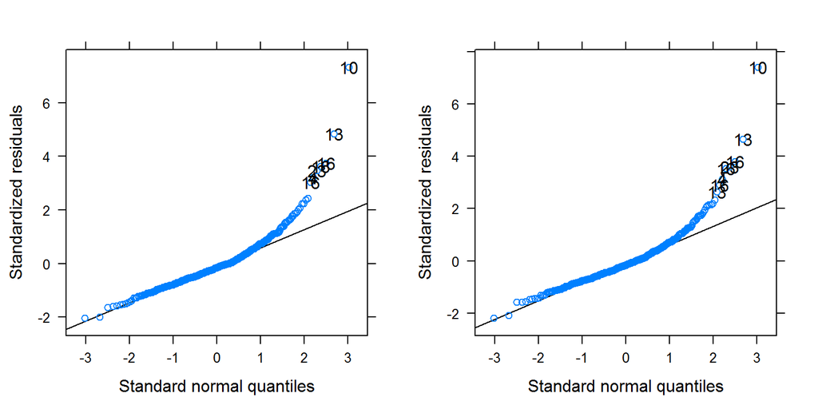

```r
qqp_m1 <- qqmath(m_con_u_1$full_model, id = 0.01, idLabels = as.character(drp_r$P.s))
qqp_m2 <- qqmath(m_con_u_3$full_model, id = 0.01, idLabels = as.character(drp_r$P.s))
grid.arrange(qqp_m1, qqp_m2, ncol = 2)
```

Again, the effect of `Fit` is not significant.

```r
nice(m_con_u_1)
```

```
## Mixed Model Anova Table (Type 3 tests, KR-method)
##
## Model: consequent ~ Fit + (Fit | P.s) + (Fit | Item)
## Data: drp_r
##   Effect       df    F p.value
## 1    Fit 1, 10.07 1.20     .30
## ---
## Signif. codes:  0 '***' 0.001 '**' 0.01 '*' 0.05 '+' 0.1 ' ' 1
```

```r
nice(m_con_u_3)
```

```
## Mixed Model Anova Table (Type 3 tests, KR-method)
##
## Model: consequent ~ Fit + (1 | P.s) + (1 | Item)
## Data: drp_r
##   Effect        df    F p.value
## 1    Fit 1, 365.36 1.33     .25
## ---
## Signif. codes:  0 '***' 0.001 '**' 0.01 '*' 0.05 '+' 0.1 ' ' 1
```

## With Fit (log-transformed RTs), Reduced Sample

We refit the logged RTs with a reduced model for which we remove one response of ID 10.

```r
outl <- (drp_r$P.s == "10" & drp_r$consequent > 4) #|
  #(drp_r$P.s == "16" & (drp_r$log_con < -1 | drp_r$log_con > 1) )
drp_r_1 <- drp_r[!outl,]
```

```r
m_fp_con_1b <- mixed(log_con ~ Fit + (Fit|P.s) + (Fit| Item), drp_r_1, progress = FALSE)
```

```
## Contrasts set to contr.sum for the following variables: Fit, P.s, Item
```

```r
summary(m_fp_con_1b)
```

```
## Linear mixed model fit by REML ['merModLmerTest']
## Formula: log_con ~ Fit + (Fit | P.s) + (Fit | Item)
##    Data: drp_r_1
##
## REML criterion at convergence: 472
##
## Scaled residuals:
##      Min       1Q   Median       3Q      Max
## -2.80154 -0.60428 -0.04057  0.58472  2.95298
##
## Random effects:
##  Groups   Name        Variance Std.Dev. Corr
##  P.s      (Intercept) 0.070047 0.26466
##           Fit1        0.002931 0.05414  0.81
##  Item     (Intercept) 0.062945 0.25089
##           Fit1        0.001399 0.03741  0.59
##  Residual             0.144865 0.38061
## Number of obs: 405, groups:  P.s, 24; Item, 17
##
## Fixed effects:
##             Estimate Std. Error t value
## (Intercept) -0.21887    0.08354  -2.620
## Fit1        -0.04478    0.02374  -1.887
##
## Correlation of Fixed Effects:
##      (Intr)
## Fit1 0.409
```

Although the correlations are not extreme, we try by removing them.

```r
m_fp_con_2b <- mixed(log_con ~ Fit + (Fit||P.s) + (Fit|| Item), drp_r_1, progress = FALSE, expand_re = TRUE)
```

```
## Contrasts set to contr.sum for the following variables: Fit, P.s, Item
```

```r
summary(m_fp_con_2b)
```

```
## Linear mixed model fit by REML ['merModLmerTest']
## Formula:
## log_con ~ Fit + ((1 | P.s) + (0 + re1.Fit1 | P.s)) + ((1 | Item) +
##     (0 + re2.Fit1 | Item))
##    Data: drp_r_1
##
## REML criterion at convergence: 476.5
##
## Scaled residuals:
##      Min       1Q   Median       3Q      Max
## -2.83286 -0.58957 -0.05224  0.56426  2.94141
##
## Random effects:
##  Groups   Name        Variance Std.Dev.
##  P.s      (Intercept) 0.069809 0.26421
##  P.s.1    re1.Fit1    0.002806 0.05297
##  Item     (Intercept) 0.063124 0.25125
##  Item.1   re2.Fit1    0.001404 0.03747
##  Residual             0.144968 0.38075
## Number of obs: 405, groups:  P.s, 24; Item, 17
##
## Fixed effects:
##             Estimate Std. Error t value
## (Intercept) -0.21826    0.08355  -2.612
## Fit1        -0.04467    0.02364  -1.890
##
## Correlation of Fixed Effects:
##      (Intr)
## Fit1 0.001
```

This does not seem to be justified when looking at likelihood-ratio tests.

```r
anova(m_fp_con_1b, m_fp_con_2b)
```

```
## Data: drp_r_1
## Models:
## m_fp_con_2b: log_con ~ Fit + ((1 | P.s) + (0 + re1.Fit1 | P.s)) + ((1 | Item) +
## m_fp_con_2b:     (0 + re2.Fit1 | Item))
## m_fp_con_1b: log_con ~ Fit + (Fit | P.s) + (Fit | Item)
##             Df    AIC    BIC  logLik deviance  Chisq Chi Df Pr(>Chisq)
## m_fp_con_2b  7 490.49 518.52 -238.25   476.49
## m_fp_con_1b  9 489.96 525.99 -235.98   471.96 4.5334      2     0.1037
```

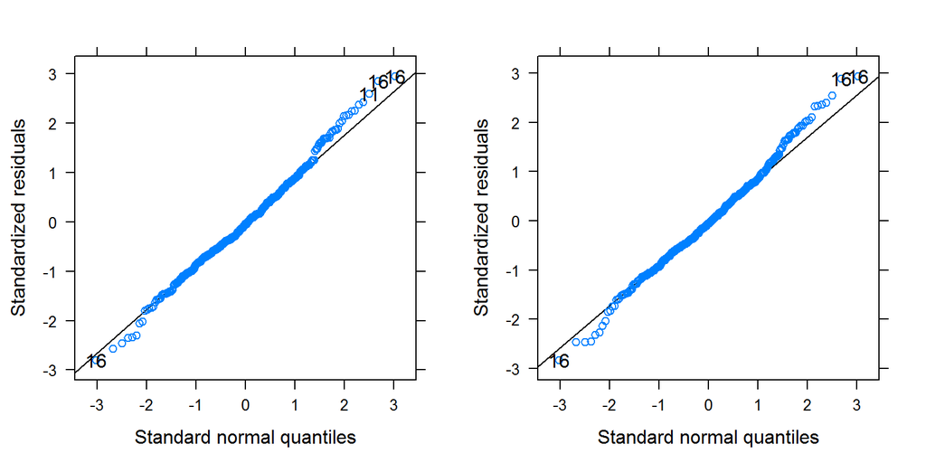

```r
qqp_m1 <- qqmath(m_fp_con_1b$full_model, id = 0.01, idLabels = as.character(drp_r_1$P.s))
qqp_m2 <- qqmath(m_fp_con_2b$full_model, id = 0.01, idLabels = as.character(drp_r_1$P.s))
grid.arrange(qqp_m1, qqp_m2, ncol = 2)
```

The effect of `Fit` is not significant for both models, but approaches significance.

```r
nice(m_fp_con_1b)
```

```
## Mixed Model Anova Table (Type 3 tests, KR-method)
##
## Model: log_con ~ Fit + (Fit | P.s) + (Fit | Item)
## Data: drp_r_1
##   Effect       df      F p.value
## 1    Fit 1, 13.33 3.56 +     .08
## ---
## Signif. codes:  0 '***' 0.001 '**' 0.01 '*' 0.05 '+' 0.1 ' ' 1
```

```r
nice(m_fp_con_2b)
```

```
## Mixed Model Anova Table (Type 3 tests, KR-method)
##
## Model: log_con ~ Fit + (Fit || P.s) + (Fit || Item)
## Data: drp_r_1
##   Effect       df      F p.value
## 1    Fit 1, 13.18 3.57 +     .08
## ---
## Signif. codes:  0 '***' 0.001 '**' 0.01 '*' 0.05 '+' 0.1 ' ' 1
```

## With Accepts (log-transformed RT and Accepts)

```r
m_fp_con_11 <- mixed(log_con ~ log_acc + (log_acc|P.s) + (Fit| Item), drp_r, progress = FALSE)
```

```
## Contrasts set to contr.sum for the following variables: P.s, Fit, Item
```

```
## Numerical variables NOT centered on 0 (i.e., interpretation of all main effects might be difficult if in interactions): log_acc
```

```r
summary(m_fp_con_11)
```

```
## Linear mixed model fit by REML ['merModLmerTest']
## Formula: log_con ~ log_acc + (log_acc | P.s) + (Fit | Item)
##    Data: drp_r
##
## REML criterion at convergence: 481
##
## Scaled residuals:
##     Min      1Q  Median      3Q     Max
## -2.7297 -0.5734 -0.0838  0.5468  4.0088
##
## Random effects:
##  Groups   Name        Variance  Std.Dev. Corr
##  P.s      (Intercept) 0.1164534 0.34125
##           log_acc     0.1333019 0.36511  -0.92
##  Item     (Intercept) 0.0653781 0.25569
##           Fit1        0.0002335 0.01528  1.00
##  Residual             0.1499741 0.38726
## Number of obs: 406, groups:  P.s, 24; Item, 17
##
## Fixed effects:
##             Estimate Std. Error t value
## (Intercept)   0.2431     0.2067   1.176
## log_acc      -0.3050     0.1490  -2.047
##
## Correlation of Fixed Effects:
##         (Intr)
## log_acc -0.926
```

We see an extreme correlation between the random-effects parameters for the by-item random effect and a slightly smaller one but still potentially problematic for the by-participant random slope..

```r
m_fp_con_12 <- mixed(log_con ~ log_acc + (log_acc||P.s) + (Fit||Item), drp_r, expand_re = TRUE, progress = FALSE)
```

```
## Contrasts set to contr.sum for the following variables: P.s, Fit, Item
```

```
## Numerical variables NOT centered on 0 (i.e., interpretation of all main effects might be difficult if in interactions): log_acc
```

```r
summary(m_fp_con_12)
```

```
## Linear mixed model fit by REML ['merModLmerTest']
## Formula:
## log_con ~ log_acc + ((1 | P.s) + (0 + re1.log_acc | P.s)) + ((1 |
##     Item) + (0 + re2.Fit1 | Item))
##    Data: drp_r
##
## REML criterion at convergence: 483.4
##
## Scaled residuals:
##     Min      1Q  Median      3Q     Max
## -2.7848 -0.5921 -0.0753  0.5524  3.9928
##
## Random effects:
##  Groups   Name        Variance  Std.Dev.
##  P.s      (Intercept) 6.068e-15 7.790e-08
##  P.s.1    re1.log_acc 3.225e-02 1.796e-01
##  Item     (Intercept) 6.518e-02 2.553e-01
##  Item.1   re2.Fit1    0.000e+00 0.000e+00
##  Residual             1.521e-01 3.899e-01
## Number of obs: 406, groups:  P.s, 24; Item, 17
##
## Fixed effects:
##             Estimate Std. Error t value
## (Intercept)   0.2644     0.2030   1.302
## log_acc      -0.3193     0.1336  -2.390
##
## Correlation of Fixed Effects:
##         (Intr)
## log_acc -0.911
```

```r
m_fp_con_13 <- mixed(log_con ~ log_acc + (0+log_acc|P.s) + (1|Item), drp_r, expand_re = FALSE, progress = FALSE)
```

```
## Contrasts set to contr.sum for the following variables: P.s, Item
```

```
## Numerical variables NOT centered on 0 (i.e., interpretation of all main effects might be difficult if in interactions): log_acc
```

```r
summary(m_fp_con_13)
```

```
## Linear mixed model fit by REML ['merModLmerTest']
## Formula: log_con ~ log_acc + (0 + log_acc | P.s) + (1 | Item)
##    Data: drp_r
##
## REML criterion at convergence: 483.4
##
## Scaled residuals:
##     Min      1Q  Median      3Q     Max
## -2.7848 -0.5921 -0.0753  0.5524  3.9928
##
## Random effects:
##  Groups   Name        Variance Std.Dev.
##  P.s      log_acc     0.03225  0.1796
##  Item     (Intercept) 0.06518  0.2553
##  Residual             0.15205  0.3899
## Number of obs: 406, groups:  P.s, 24; Item, 17
##
## Fixed effects:
##             Estimate Std. Error t value
## (Intercept)   0.2644     0.2030   1.302
## log_acc      -0.3193     0.1336  -2.390
##
## Correlation of Fixed Effects:
##         (Intr)
## log_acc -0.911
```

The reduced model seems to provide the best account.

```r
anova(m_fp_con_11, m_fp_con_12, m_fp_con_13)
```

```
## Data: drp_r
## Models:
## m_fp_con_13: log_con ~ log_acc + (0 + log_acc | P.s) + (1 | Item)
## m_fp_con_12: log_con ~ log_acc + ((1 | P.s) + (0 + re1.log_acc | P.s)) + ((1 |
## m_fp_con_12:     Item) + (0 + re2.Fit1 | Item))
## m_fp_con_11: log_con ~ log_acc + (log_acc | P.s) + (Fit | Item)
##             Df    AIC    BIC  logLik deviance  Chisq Chi Df Pr(>Chisq)
## m_fp_con_13  5 493.43 513.46 -241.72   483.43
## m_fp_con_12  7 497.43 525.48 -241.72   483.43 0.0000      2     1.0000
## m_fp_con_11  9 499.05 535.10 -240.52   481.05 2.3865      2     0.3032
```

However, we again see some departure from normality. Especially again for participant 10.

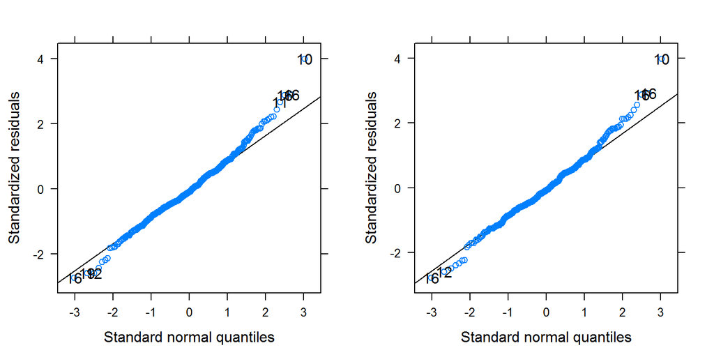

```r
qqp_11 <- qqmath(m_fp_con_11$full_model, id = 0.01, idLabels = as.character(drp_r$P.s))
qqp_12 <- qqmath(m_fp_con_13$full_model, id = 0.01, idLabels = as.character(drp_r$P.s))
grid.arrange(qqp_11, qqp_12, ncol = 2)
```

The models that fit well show a significant effect of `log_acc`, the first model not so much.

```r
nice(m_fp_con_11)
```

```
## Mixed Model Anova Table (Type 3 tests, KR-method)
##
## Model: log_con ~ log_acc + (log_acc | P.s) + (Fit | Item)
## Data: drp_r
##    Effect       df      F p.value
## 1 log_acc 1, 16.79 3.94 +     .06
## ---
## Signif. codes:  0 '***' 0.001 '**' 0.01 '*' 0.05 '+' 0.1 ' ' 1
```

```r
nice(m_fp_con_12)
```

```
## Mixed Model Anova Table (Type 3 tests, KR-method)
##
## Model: log_con ~ log_acc + (log_acc || P.s) + (Fit || Item)
## Data: drp_r
##    Effect       df      F p.value
## 1 log_acc 1, 18.83 5.57 *     .03
## ---
## Signif. codes:  0 '***' 0.001 '**' 0.01 '*' 0.05 '+' 0.1 ' ' 1
```

```r
nice(m_fp_con_13)
```

```
## Mixed Model Anova Table (Type 3 tests, KR-method)
##
## Model: log_con ~ log_acc + (0 + log_acc | P.s) + (1 | Item)
## Data: drp_r
##    Effect        df      F p.value
## 1 log_acc 1, 398.13 5.65 *     .02
## ---
## Signif. codes:  0 '***' 0.001 '**' 0.01 '*' 0.05 '+' 0.1 ' ' 1
```

## With Accepts (log-transformed RTs)

```r
m_fp_con_21 <- mixed(log_con ~ acc_z + (acc_z|P.s) + (Fit| Item), drp_r, progress = FALSE)
```

```
## Contrasts set to contr.sum for the following variables: P.s, Fit, Item
```

```r
summary(m_fp_con_21)
```

```
## Linear mixed model fit by REML ['merModLmerTest']
## Formula: log_con ~ acc_z + (acc_z | P.s) + (Fit | Item)
##    Data: drp_r
##
## REML criterion at convergence: 484.6
##
## Scaled residuals:
##     Min      1Q  Median      3Q     Max
## -2.7231 -0.5777 -0.0899  0.5429  4.0243
##
## Random effects:
##  Groups   Name        Variance  Std.Dev. Corr
##  P.s      (Intercept) 0.0703215 0.26518
##           acc_z       0.0043148 0.06569  0.88
##  Item     (Intercept) 0.0647854 0.25453
##           Fit1        0.0002549 0.01597  1.00
##  Residual             0.1502211 0.38758
## Number of obs: 406, groups:  P.s, 24; Item, 17
##
## Fixed effects:
##             Estimate Std. Error t value
## (Intercept) -0.21440    0.08405  -2.551
## acc_z       -0.05685    0.02723  -2.088
##
## Correlation of Fixed Effects:
##       (Intr)
## acc_z 0.383
```

```r
m_fp_con_22 <- mixed(log_con ~ acc_z + (acc_z|P.s) + (Fit||Item), drp_r, expand_re = TRUE, progress = FALSE)
```

```
## Contrasts set to contr.sum for the following variables: P.s, Fit, Item
```

```r
summary(m_fp_con_22)
```

```
## Linear mixed model fit by REML ['merModLmerTest']
## Formula: log_con ~ acc_z + (1 + re1.acc_z | P.s) + ((1 | Item) + (0 +
##     re2.Fit1 | Item))
##    Data: drp_r
##
## REML criterion at convergence: 485.2
##
## Scaled residuals:
##     Min      1Q  Median      3Q     Max
## -2.7162 -0.5765 -0.0865  0.5422  4.0129
##
## Random effects:
##  Groups   Name        Variance Std.Dev. Corr
##  P.s      (Intercept) 0.070307 0.2652
##           re1.acc_z   0.004449 0.0667   0.87
##  Item     (Intercept) 0.064752 0.2545
##  Item.1   re2.Fit1    0.000000 0.0000
##  Residual             0.150441 0.3879
## Number of obs: 406, groups:  P.s, 24; Item, 17
##
## Fixed effects:
##             Estimate Std. Error t value
## (Intercept) -0.21346    0.08432  -2.532
## acc_z       -0.05698    0.02707  -2.105
##
## Correlation of Fixed Effects:
##       (Intr)
## acc_z 0.282
```

We then also remove the by-item random slopes.

```r
m_fp_con_23 <- mixed(log_con ~ acc_z + (acc_z|P.s) + (1|Item), drp_r,
                     expand_re = TRUE, progress = FALSE)
```

```
## Contrasts set to contr.sum for the following variables: P.s, Item
```

```r
summary(m_fp_con_23)
```

```
## Linear mixed model fit by REML ['merModLmerTest']
## Formula: log_con ~ acc_z + (1 + re1.acc_z | P.s) + (1 | Item)
##    Data: drp_r
##
## REML criterion at convergence: 485.2
##
## Scaled residuals:
##     Min      1Q  Median      3Q     Max
## -2.7162 -0.5765 -0.0865  0.5422  4.0129
##
## Random effects:
##  Groups   Name        Variance Std.Dev. Corr
##  P.s      (Intercept) 0.070307 0.2652
##           re1.acc_z   0.004449 0.0667   0.87
##  Item     (Intercept) 0.064752 0.2545
##  Residual             0.150441 0.3879
## Number of obs: 406, groups:  P.s, 24; Item, 17
##
## Fixed effects:
##             Estimate Std. Error t value
## (Intercept) -0.21346    0.08432  -2.532
## acc_z       -0.05698    0.02707  -2.105
##
## Correlation of Fixed Effects:
##       (Intr)
## acc_z 0.282
```

```r
anova(m_fp_con_21, m_fp_con_22, m_fp_con_23)
```

```
## Data: drp_r
## Models:
## m_fp_con_23: log_con ~ acc_z + (1 + re1.acc_z | P.s) + (1 | Item)
## m_fp_con_22: log_con ~ acc_z + (1 + re1.acc_z | P.s) + ((1 | Item) + (0 +
## m_fp_con_22:     re2.Fit1 | Item))
## m_fp_con_21: log_con ~ acc_z + (acc_z | P.s) + (Fit | Item)
##             Df    AIC    BIC  logLik deviance Chisq Chi Df Pr(>Chisq)
## m_fp_con_23  7 499.23 527.27 -242.61   485.23
## m_fp_con_22  8 501.23 533.28 -242.61   485.23 0.000      1      1.000
## m_fp_con_21  9 502.63 538.69 -242.31   484.63 0.599      1      0.439
```

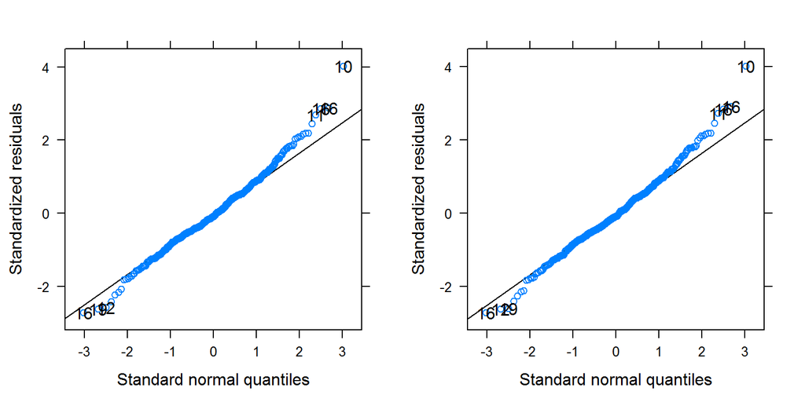

```r
qqp_21 <- qqmath(m_fp_con_21$full_model, id = 0.01, idLabels = as.character(drp_r$P.s))
qqp_22 <- qqmath(m_fp_con_23$full_model, id = 0.01, idLabels = as.character(drp_r$P.s))
grid.arrange(qqp_21, qqp_22, ncol = 2)
```

Furthermore, the maximally reduced model shows a significant effect of `Accepts` (z-transformed to `acc_z`).

```r
nice(m_fp_con_21)
```

```
## Mixed Model Anova Table (Type 3 tests, KR-method)
##
## Model: log_con ~ acc_z + (acc_z | P.s) + (Fit | Item)
## Data: drp_r
##   Effect       df      F p.value
## 1  acc_z 1, 16.60 4.12 +     .06
## ---
## Signif. codes:  0 '***' 0.001 '**' 0.01 '*' 0.05 '+' 0.1 ' ' 1
```

```r
nice(m_fp_con_22)
```

```
## Mixed Model Anova Table (Type 3 tests, KR-method)
##
## Model: log_con ~ acc_z + (acc_z | P.s) + (Fit || Item)
## Data: drp_r
##   Effect       df      F p.value
## 1  acc_z 1, 16.38 4.33 +     .05
## ---
## Signif. codes:  0 '***' 0.001 '**' 0.01 '*' 0.05 '+' 0.1 ' ' 1
```

```r
nice(m_fp_con_23)
```

```
## Mixed Model Anova Table (Type 3 tests, KR-method)
##
## Model: log_con ~ acc_z + (acc_z | P.s) + (1 | Item)
## Data: drp_r
##   Effect       df      F p.value
## 1  acc_z 1, 36.07 4.37 *     .04
## ---
## Signif. codes:  0 '***' 0.001 '**' 0.01 '*' 0.05 '+' 0.1 ' ' 1
```

## With Accepts (log-transformed RTs and reduced data set)

```r
m_con_ar_1 <- mixed(log_con ~ acc_z + (acc_z|P.s) + (Fit| Item),
                           drp_r_1, progress = FALSE)
```

```
## Contrasts set to contr.sum for the following variables: P.s, Fit, Item
```

```
## Numerical variables NOT centered on 0 (i.e., interpretation of all main effects might be difficult if in interactions): acc_z
```

```r
summary(m_con_ar_1)
```

```
## Linear mixed model fit by REML ['merModLmerTest']
## Formula: log_con ~ acc_z + (acc_z | P.s) + (Fit | Item)
##    Data: drp_r_1
##
## REML criterion at convergence: 466.2
##
## Scaled residuals:
##      Min       1Q   Median       3Q      Max
## -2.80195 -0.58397 -0.09291  0.56327  2.93676
##
## Random effects:
##  Groups   Name        Variance  Std.Dev. Corr
##  P.s      (Intercept) 0.0693173 0.26328
##           acc_z       0.0045440 0.06741  0.84
##  Item     (Intercept) 0.0663114 0.25751
##           Fit1        0.0003277 0.01810  1.00
##  Residual             0.1429163 0.37804
## Number of obs: 405, groups:  P.s, 24; Item, 17
##
## Fixed effects:
##             Estimate Std. Error t value
## (Intercept) -0.21735    0.08413  -2.584
## acc_z       -0.05997    0.02705  -2.217
##
## Correlation of Fixed Effects:
##       (Intr)
## acc_z 0.393
```

We remove the correlations among the by-item random effects.

```r
m_con_ar_2 <- mixed(log_con ~ acc_z + (acc_z|P.s) + (Fit || Item),
                           drp_r_1, progress = FALSE, expand_re = TRUE)
```

```
## Contrasts set to contr.sum for the following variables: P.s, Fit, Item
```

```
## Numerical variables NOT centered on 0 (i.e., interpretation of all main effects might be difficult if in interactions): acc_z
```

```r
summary(m_con_ar_2)
```

```
## Linear mixed model fit by REML ['merModLmerTest']
## Formula: log_con ~ acc_z + (1 + re1.acc_z | P.s) + ((1 | Item) + (0 +
##     re2.Fit1 | Item))
##    Data: drp_r_1
##
## REML criterion at convergence: 467
##
## Scaled residuals:
##      Min       1Q   Median       3Q      Max
## -2.79276 -0.59226 -0.09238  0.56485  2.96984
##
## Random effects:
##  Groups   Name        Variance Std.Dev. Corr
##  P.s      (Intercept) 0.069276 0.26320
##           re1.acc_z   0.004693 0.06851  0.84
##  Item     (Intercept) 0.066279 0.25745
##  Item.1   re2.Fit1    0.000000 0.00000
##  Residual             0.143207 0.37843
## Number of obs: 405, groups:  P.s, 24; Item, 17
##
## Fixed effects:
##             Estimate Std. Error t value
## (Intercept) -0.21766    0.08449  -2.576
## acc_z       -0.06011    0.02683  -2.241
##
## Correlation of Fixed Effects:
##       (Intr)
## acc_z 0.278
```

We now also remove the random slope estimatewd to be zero.

```r
m_con_ar_3 <- mixed(log_con ~ acc_z + (acc_z|P.s) + (1 | Item),
                           drp_r_1, progress = FALSE, expand_re = FALSE)
```

```
## Contrasts set to contr.sum for the following variables: P.s, Item
```

```
## Numerical variables NOT centered on 0 (i.e., interpretation of all main effects might be difficult if in interactions): acc_z
```

```r
summary(m_con_ar_3)
```

```
## Linear mixed model fit by REML ['merModLmerTest']
## Formula: log_con ~ acc_z + (acc_z | P.s) + (1 | Item)
##    Data: drp_r_1
##
## REML criterion at convergence: 467
##
## Scaled residuals:
##      Min       1Q   Median       3Q      Max
## -2.79276 -0.59226 -0.09238  0.56485  2.96984
##
## Random effects:
##  Groups   Name        Variance Std.Dev. Corr
##  P.s      (Intercept) 0.069276 0.26320
##           acc_z       0.004693 0.06851  0.84
##  Item     (Intercept) 0.066279 0.25745
##  Residual             0.143207 0.37843
## Number of obs: 405, groups:  P.s, 24; Item, 17
##
## Fixed effects:
##             Estimate Std. Error t value
## (Intercept) -0.21766    0.08449  -2.576
## acc_z       -0.06011    0.02683  -2.241
##
## Correlation of Fixed Effects:
##       (Intr)
## acc_z 0.278
```

```r
anova(m_con_ar_1, m_con_ar_2, m_con_ar_3)
```

```
## Data: drp_r_1
## Models:
## m_con_ar_3: log_con ~ acc_z + (acc_z | P.s) + (1 | Item)
## m_con_ar_2: log_con ~ acc_z + (1 + re1.acc_z | P.s) + ((1 | Item) + (0 +
## m_con_ar_2:     re2.Fit1 | Item))
## m_con_ar_1: log_con ~ acc_z + (acc_z | P.s) + (Fit | Item)
##            Df    AIC    BIC  logLik deviance  Chisq Chi Df Pr(>Chisq)
## m_con_ar_3  7 480.97 508.99 -233.48   466.97
## m_con_ar_2  8 482.97 515.00 -233.48   466.97 0.0000      1     1.0000
## m_con_ar_1  9 484.16 520.19 -233.08   466.16 0.8076      1     0.3688
```

The best model appears to be the maximally reduced model. In addition, the QQ-plots shows comparatively mild violations.

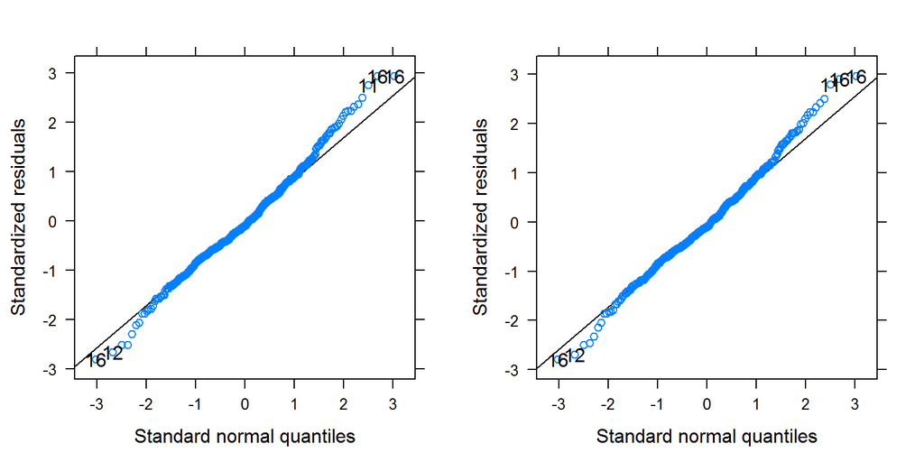

```r
qqp_21 <- qqmath(m_con_ar_1$full_model, id = 0.01, idLabels = as.character(drp_r_1$P.s))
qqp_22 <- qqmath(m_con_ar_3$full_model, id = 0.01, idLabels = as.character(drp_r_1$P.s))
grid.arrange(qqp_21, qqp_22, ncol = 2)
```

Furthermore, now all models show a significant effect of `Accepts` (z-transformed to `acc_z`).

```r
nice(m_con_ar_1)
```

```
## Mixed Model Anova Table (Type 3 tests, KR-method)
##
## Model: log_con ~ acc_z + (acc_z | P.s) + (Fit | Item)
## Data: drp_r_1
##   Effect       df      F p.value
## 1  acc_z 1, 17.00 4.65 *     .05
## ---
## Signif. codes:  0 '***' 0.001 '**' 0.01 '*' 0.05 '+' 0.1 ' ' 1
```

```r
nice(m_con_ar_2)
```

```
## Mixed Model Anova Table (Type 3 tests, KR-method)
##
## Model: log_con ~ acc_z + (acc_z | P.s) + (Fit || Item)
## Data: drp_r_1
##   Effect       df      F p.value
## 1  acc_z 1, 16.68 4.92 *     .04
## ---
## Signif. codes:  0 '***' 0.001 '**' 0.01 '*' 0.05 '+' 0.1 ' ' 1
```

```r
nice(m_con_ar_3)
```

```
## Mixed Model Anova Table (Type 3 tests, KR-method)
##
## Model: log_con ~ acc_z + (acc_z | P.s) + (1 | Item)
## Data: drp_r_1
##   Effect       df      F p.value
## 1  acc_z 1, 35.58 4.95 *     .03
## ---
## Signif. codes:  0 '***' 0.001 '**' 0.01 '*' 0.05 '+' 0.1 ' ' 1
```

# Spillover

## With Fit (log-transformed RTs)

```r
m_fp_spill_f_1 <- mixed(log_spill ~ Fit + (Fit|P.s) + (Fit| Item), drp_r, progress = FALSE)
```

```
## Contrasts set to contr.sum for the following variables: Fit, P.s, Item
```

```r
summary(m_fp_spill_f_1)
```

```
## Linear mixed model fit by REML ['merModLmerTest']
## Formula: log_spill ~ Fit + (Fit | P.s) + (Fit | Item)
##    Data: drp_r
##
## REML criterion at convergence: 345.6
##
## Scaled residuals:
##     Min      1Q  Median      3Q     Max
## -3.2703 -0.5107  0.0394  0.5940  2.8526
##
## Random effects:
##  Groups   Name        Variance  Std.Dev. Corr
##  P.s      (Intercept) 5.872e-02 0.242331
##           Fit1        9.064e-05 0.009520 -1.00
##  Item     (Intercept) 4.174e-02 0.204292
##           Fit1        1.781e-06 0.001334 1.00
##  Residual             1.067e-01 0.326687
## Number of obs: 406, groups:  P.s, 24; Item, 17
##
## Fixed effects:
##              Estimate Std. Error t value
## (Intercept)  0.727997   0.071867  10.130
## Fit1        -0.002063   0.016357  -0.126
##
## Correlation of Fixed Effects:
##      (Intr)
## Fit1 -0.067
```

Due to the large correlation between the by-participants and by-item random-effects parameters we refit the model without the correlations.

```r
m_fp_spill_f_2 <- mixed(log_spill ~ Fit + (Fit||P.s) + (Fit||Item), drp_r, expand_re = TRUE, progress = FALSE)
```

```
## Contrasts set to contr.sum for the following variables: Fit, P.s, Item
```

```r
summary(m_fp_spill_f_2)
```

```
## Linear mixed model fit by REML ['merModLmerTest']
## Formula: log_spill ~ Fit + ((1 | P.s) + (0 + re1.Fit1 | P.s)) + ((1 |
##     Item) + (0 + re2.Fit1 | Item))
##    Data: drp_r
##
## REML criterion at convergence: 345.9
##
## Scaled residuals:
##     Min      1Q  Median      3Q     Max
## -3.2435 -0.5028  0.0438  0.5965  2.8763
##
## Random effects:
##  Groups   Name        Variance Std.Dev.
##  P.s      (Intercept) 0.05874  0.2424
##  P.s.1    re1.Fit1    0.00000  0.0000
##  Item     (Intercept) 0.04159  0.2039
##  Item.1   re2.Fit1    0.00000  0.0000
##  Residual             0.10684  0.3269
## Number of obs: 406, groups:  P.s, 24; Item, 17
##
## Fixed effects:
##              Estimate Std. Error t value
## (Intercept)  0.727797   0.071814  10.135
## Fit1        -0.002129   0.016246  -0.131
##
## Correlation of Fixed Effects:
##      (Intr)
## Fit1 0.001
```

Now both random slopes are estimated to be zero, we consequently refit the model without those parameters.

```r
m_fp_spill_f_3 <- mixed(log_spill ~ Fit + (1|P.s) + (1| Item), drp_r, progress = FALSE)
```

```
## Contrasts set to contr.sum for the following variables: Fit, P.s, Item
```

```r
summary(m_fp_spill_f_3)
```

```
## Linear mixed model fit by REML ['merModLmerTest']
## Formula: log_spill ~ Fit + (1 | P.s) + (1 | Item)
##    Data: drp_r
##
## REML criterion at convergence: 345.9
##
## Scaled residuals:
##     Min      1Q  Median      3Q     Max
## -3.2435 -0.5028  0.0438  0.5965  2.8763
##
## Random effects:
##  Groups   Name        Variance Std.Dev.
##  P.s      (Intercept) 0.05874  0.2424
##  Item     (Intercept) 0.04159  0.2039
##  Residual             0.10684  0.3269
## Number of obs: 406, groups:  P.s, 24; Item, 17
##
## Fixed effects:
##              Estimate Std. Error t value
## (Intercept)  0.727797   0.071814  10.135
## Fit1        -0.002129   0.016246  -0.131
##
## Correlation of Fixed Effects:
##      (Intr)
## Fit1 0.001
```

Again the final model appears to be the optimal model.

```r
anova(m_fp_spill_f_1, m_fp_spill_f_3)
```

```
## Data: drp_r
## Models:
## m_fp_spill_f_3: log_spill ~ Fit + (1 | P.s) + (1 | Item)
## m_fp_spill_f_1: log_spill ~ Fit + (Fit | P.s) + (Fit | Item)
##                Df    AIC    BIC  logLik deviance  Chisq Chi Df Pr(>Chisq)
## m_fp_spill_f_3  5 355.92 375.95 -172.96   345.92
## m_fp_spill_f_1  9 363.62 399.68 -172.81   345.62 0.3005      4     0.9898
```

The QQ-plot again shows a clear deviation from normality for fast responses.

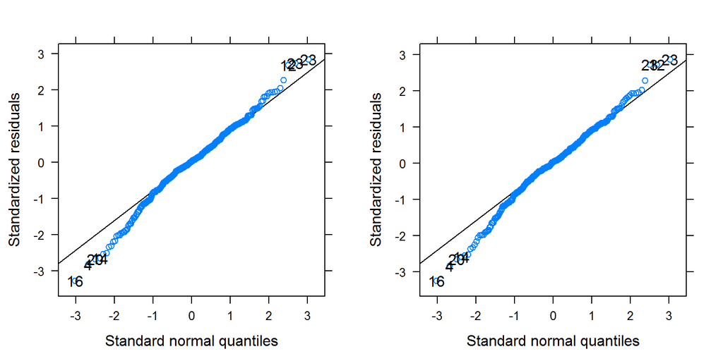

```r
qqp_m1 <- qqmath(m_fp_spill_f_1$full_model, id = 0.01, idLabels = as.character(drp_r$P.s))
qqp_m2 <- qqmath(m_fp_spill_f_3$full_model, id = 0.01, idLabels = as.character(drp_r$P.s))
grid.arrange(qqp_m1, qqp_m2, ncol = 2)
```

The effect of `Fit` is not significant.

```r
nice(m_fp_spill_f_1)
```

```
## Mixed Model Anova Table (Type 3 tests, KR-method)
##
## Model: log_spill ~ Fit + (Fit | P.s) + (Fit | Item)
## Data: drp_r
##   Effect      df    F p.value
## 1    Fit 1, 8.84 0.02     .90
## ---
## Signif. codes:  0 '***' 0.001 '**' 0.01 '*' 0.05 '+' 0.1 ' ' 1
```

```r
nice(m_fp_spill_f_3)
```

```
## Mixed Model Anova Table (Type 3 tests, KR-method)
##
## Model: log_spill ~ Fit + (1 | P.s) + (1 | Item)
## Data: drp_r
##   Effect        df    F p.value
## 1    Fit 1, 365.24 0.02     .90
## ---
## Signif. codes:  0 '***' 0.001 '**' 0.01 '*' 0.05 '+' 0.1 ' ' 1
```

## With Fit (log-transformed RTs and reduced data set)

We again reduce the data set by one observation with a fast RT for participant 16.

```r
out_spill <- (drp_r$P.s == "16" & drp_r$spillover < 1.0 )
drp_r_r2 <- drp_r[!out_spill,]
drp_r_r2$spilloverw <- as.vector(LambertW::Gaussianize(drp_r_r2$spillover,
                                                        type = "h", method = "MLE"))
```

```r
m_fp_spill_fr_1 <- mixed(log_spill ~ Fit + (Fit|P.s) + (Fit| Item), drp_r_r2, progress = FALSE)
```

```
## Contrasts set to contr.sum for the following variables: Fit, P.s, Item
```

```r
summary(m_fp_spill_fr_1)
```

```
## Linear mixed model fit by REML ['merModLmerTest']
## Formula: log_spill ~ Fit + (Fit | P.s) + (Fit | Item)
##    Data: drp_r_r2
##
## REML criterion at convergence: 333.8
##
## Scaled residuals:
##      Min       1Q   Median       3Q      Max
## -2.81989 -0.51623  0.02662  0.59921  2.88912
##
## Random effects:
##  Groups   Name        Variance  Std.Dev. Corr
##  P.s      (Intercept) 6.081e-02 0.246595
##           Fit1        1.664e-04 0.012899 -1.00
##  Item     (Intercept) 4.034e-02 0.200843
##           Fit1        2.298e-05 0.004793 1.00
##  Residual             1.035e-01 0.321683
## Number of obs: 405, groups:  P.s, 24; Item, 17
##
## Fixed effects:
##              Estimate Std. Error t value
## (Intercept)  0.730974   0.071849  10.174
## Fit1        -0.005148   0.016270  -0.316
##
## Correlation of Fixed Effects:
##      (Intr)
## Fit1 -0.064
```

Due to the large correlation between the by-participants and by-item random-effects parameters we refit the model without the correlations.

```r
m_fp_spill_fr_2 <- mixed(log_spill ~ Fit + (Fit||P.s) + (Fit|| Item), drp_r_r2, progress = FALSE, expand_re = TRUE)
```

```
## Contrasts set to contr.sum for the following variables: Fit, P.s, Item
```

```r
summary(m_fp_spill_fr_2)
```

```
## Linear mixed model fit by REML ['merModLmerTest']
## Formula: log_spill ~ Fit + ((1 | P.s) + (0 + re1.Fit1 | P.s)) + ((1 |
##     Item) + (0 + re2.Fit1 | Item))
##    Data: drp_r_r2
##
## REML criterion at convergence: 334.5
##
## Scaled residuals:
##      Min       1Q   Median       3Q      Max
## -2.85675 -0.50674  0.03035  0.58476  2.91524
##
## Random effects:
##  Groups   Name        Variance Std.Dev.
##  P.s      (Intercept) 0.06083  0.2466
##  P.s.1    re1.Fit1    0.00000  0.0000
##  Item     (Intercept) 0.04017  0.2004
##  Item.1   re2.Fit1    0.00000  0.0000
##  Residual             0.10369  0.3220
## Number of obs: 405, groups:  P.s, 24; Item, 17
##
## Fixed effects:
##              Estimate Std. Error t value
## (Intercept)  0.730628   0.071789  10.177
## Fit1        -0.005214   0.016030  -0.325
##
## Correlation of Fixed Effects:
##      (Intr)
## Fit1 0.001
```

Now both random slopes are estimated to be virtually zero, we consequently refit the model without those parameters.

```r
m_fp_spill_fr_3 <- mixed(log_spill ~ Fit + (1|P.s) + (1| Item), drp_r_r2, progress = FALSE)
```

```
## Contrasts set to contr.sum for the following variables: Fit, P.s, Item
```

```r
summary(m_fp_spill_fr_3)
```

```
## Linear mixed model fit by REML ['merModLmerTest']
## Formula: log_spill ~ Fit + (1 | P.s) + (1 | Item)
##    Data: drp_r_r2
##
## REML criterion at convergence: 334.5
##
## Scaled residuals:
##      Min       1Q   Median       3Q      Max
## -2.85675 -0.50674  0.03035  0.58476  2.91524
##
## Random effects:
##  Groups   Name        Variance Std.Dev.
##  P.s      (Intercept) 0.06083  0.2466
##  Item     (Intercept) 0.04017  0.2004
##  Residual             0.10369  0.3220
## Number of obs: 405, groups:  P.s, 24; Item, 17
##
## Fixed effects:
##              Estimate Std. Error t value
## (Intercept)  0.730628   0.071789  10.177
## Fit1        -0.005214   0.016030  -0.325
##
## Correlation of Fixed Effects:
##      (Intr)
## Fit1 0.001
```

Again the final model appears to be the optimal model.

```r
anova(m_fp_spill_fr_1, m_fp_spill_fr_2, m_fp_spill_fr_3)
```

```
## Data: drp_r_r2
## Models:
## m_fp_spill_fr_3: log_spill ~ Fit + (1 | P.s) + (1 | Item)
## m_fp_spill_fr_2: log_spill ~ Fit + ((1 | P.s) + (0 + re1.Fit1 | P.s)) + ((1 |
## m_fp_spill_fr_2:     Item) + (0 + re2.Fit1 | Item))
## m_fp_spill_fr_1: log_spill ~ Fit + (Fit | P.s) + (Fit | Item)
##                 Df    AIC    BIC  logLik deviance  Chisq Chi Df Pr(>Chisq)
## m_fp_spill_fr_3  5 344.46 364.48 -167.23   334.46
## m_fp_spill_fr_2  7 348.46 376.49 -167.23   334.46 0.0000      2     1.0000
## m_fp_spill_fr_1  9 351.84 387.87 -166.92   333.84 0.6272      2     0.7308
```

The QQ-plot now only shows comparatively mild violations at the edges.

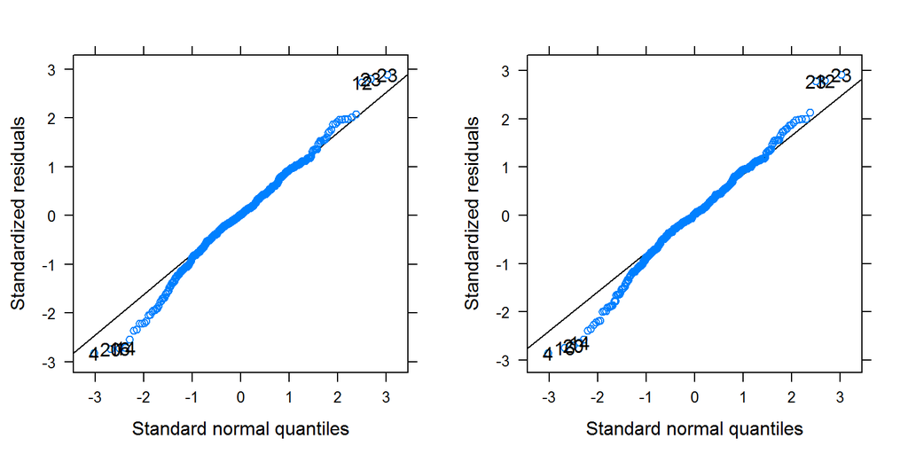

```r
qqp_m1 <- qqmath(m_fp_spill_fr_1$full_model, id = 0.01, idLabels = as.character(drp_r_r2$P.s))
qqp_m2 <- qqmath(m_fp_spill_fr_3$full_model, id = 0.01, idLabels = as.character(drp_r_r2$P.s))
grid.arrange(qqp_m1, qqp_m2, ncol = 2)
```

```r
nice(m_fp_spill_fr_1)
```

```
## Mixed Model Anova Table (Type 3 tests, KR-method)
##
## Model: log_spill ~ Fit + (Fit | P.s) + (Fit | Item)
## Data: drp_r_r2
##   Effect      df    F p.value
## 1    Fit 1, 9.01 0.10     .76
## ---
## Signif. codes:  0 '***' 0.001 '**' 0.01 '*' 0.05 '+' 0.1 ' ' 1
```

```r
nice(m_fp_spill_fr_3)
```

```
## Mixed Model Anova Table (Type 3 tests, KR-method)
##
## Model: log_spill ~ Fit + (1 | P.s) + (1 | Item)
## Data: drp_r_r2
##   Effect        df    F p.value
## 1    Fit 1, 364.27 0.11     .75
## ---
## Signif. codes:  0 '***' 0.001 '**' 0.01 '*' 0.05 '+' 0.1 ' ' 1
```

## With Accepts (log-transformed RTs and Accepts)

```r
m_fp_spill_al_1 <- mixed(log_spill ~ log_acc + (log_acc|P.s) + (Fit| Item),
                         drp_r, progress = FALSE)
```

```
## Contrasts set to contr.sum for the following variables: P.s, Fit, Item
```

```
## Numerical variables NOT centered on 0 (i.e., interpretation of all main effects might be difficult if in interactions): log_acc
```

```r
summary(m_fp_spill_al_1)
```

```
## Linear mixed model fit by REML ['merModLmerTest']
## Formula: log_spill ~ log_acc + (log_acc | P.s) + (Fit | Item)
##    Data: drp_r
##
## REML criterion at convergence: 341.5
##
## Scaled residuals:
##     Min      1Q  Median      3Q     Max
## -3.2610 -0.5063  0.0383  0.5904  2.7859
##
## Random effects:
##  Groups   Name        Variance  Std.Dev. Corr
##  P.s      (Intercept) 1.077e-01 0.32811
##           log_acc     3.282e-03 0.05729  -1.00
##  Item     (Intercept) 4.172e-02 0.20424
##           Fit1        6.967e-06 0.00264  1.00
##  Residual             1.066e-01 0.32653
## Number of obs: 406, groups:  P.s, 24; Item, 17
##
## Fixed effects:
##             Estimate Std. Error t value
## (Intercept)  0.82426    0.18025   4.573
## log_acc     -0.06478    0.10789  -0.600
##
## Correlation of Fixed Effects:
##         (Intr)
## log_acc -0.917
```

This model has correlations at the boundary of the parameter space. We refit the model without the correlations.

```r
m_fp_spill_al_2 <- mixed(log_spill ~ log_acc + (log_acc||P.s) + (Fit|| Item),
                         drp_r, progress = FALSE, expand_re = TRUE)
```

```
## Contrasts set to contr.sum for the following variables: P.s, Fit, Item
```

```
## Numerical variables NOT centered on 0 (i.e., interpretation of all main effects might be difficult if in interactions): log_acc
```

```r
summary(m_fp_spill_al_2)
```

```
## Linear mixed model fit by REML ['merModLmerTest']
## Formula: log_spill ~ log_acc + ((1 | P.s) + (0 + re1.log_acc | P.s)) +
##     ((1 | Item) + (0 + re2.Fit1 | Item))
##    Data: drp_r
##
## REML criterion at convergence: 341.9
##
## Scaled residuals:
##     Min      1Q  Median      3Q     Max
## -3.2548 -0.5069  0.0339  0.5907  2.8158
##
## Random effects:
##  Groups   Name        Variance Std.Dev.
##  P.s      (Intercept) 0.05875  0.2424
##  P.s.1    re1.log_acc 0.00000  0.0000
##  Item     (Intercept) 0.04147  0.2037
##  Item.1   re2.Fit1    0.00000  0.0000
##  Residual             0.10676  0.3267
## Number of obs: 406, groups:  P.s, 24; Item, 17
##
## Fixed effects:
##             Estimate Std. Error t value
## (Intercept)  0.81561    0.17608   4.632
## log_acc     -0.05863    0.10736  -0.546
##
## Correlation of Fixed Effects:
##         (Intr)
## log_acc -0.913
```

The by-item random slope is zero hence we refit the model without it.

```r
m_fp_spill_al_3 <- mixed(log_spill ~ log_acc + (log_acc||P.s) + (1| Item),
                         drp_r, progress = FALSE, expand_re = TRUE)
```

```
## Contrasts set to contr.sum for the following variables: P.s, Item
```

```
## Numerical variables NOT centered on 0 (i.e., interpretation of all main effects might be difficult if in interactions): log_acc
```

```r
summary(m_fp_spill_al_3)
```

```
## Linear mixed model fit by REML ['merModLmerTest']
## Formula: log_spill ~ log_acc + ((1 | P.s) + (0 + re1.log_acc | P.s)) +
##     (1 | Item)
##    Data: drp_r
##
## REML criterion at convergence: 341.9
##
## Scaled residuals:
##     Min      1Q  Median      3Q     Max
## -3.2548 -0.5069  0.0339  0.5907  2.8158
##
## Random effects:
##  Groups   Name        Variance Std.Dev.
##  P.s      (Intercept) 0.05875  0.2424
##  P.s.1    re1.log_acc 0.00000  0.0000
##  Item     (Intercept) 0.04147  0.2037
##  Residual             0.10676  0.3267
## Number of obs: 406, groups:  P.s, 24; Item, 17
##
## Fixed effects:
##             Estimate Std. Error t value
## (Intercept)  0.81561    0.17608   4.632
## log_acc     -0.05863    0.10736  -0.546
##
## Correlation of Fixed Effects:
##         (Intr)
## log_acc -0.913
```

Overall the best model appears to be the most reduced model 3.

```r
anova(m_fp_spill_al_1,m_fp_spill_al_2, m_fp_spill_al_3)
```

```
## Data: drp_r
## Models:
## m_fp_spill_al_3: log_spill ~ log_acc + ((1 | P.s) + (0 + re1.log_acc | P.s)) +
## m_fp_spill_al_3:     (1 | Item)
## m_fp_spill_al_2: log_spill ~ log_acc + ((1 | P.s) + (0 + re1.log_acc | P.s)) +
## m_fp_spill_al_2:     ((1 | Item) + (0 + re2.Fit1 | Item))
## m_fp_spill_al_1: log_spill ~ log_acc + (log_acc | P.s) + (Fit | Item)
##                 Df    AIC    BIC  logLik deviance  Chisq Chi Df Pr(>Chisq)
## m_fp_spill_al_3  6 353.86 377.90 -170.93   341.86
## m_fp_spill_al_2  7 355.86 383.91 -170.93   341.86 0.0000      1     1.0000
## m_fp_spill_al_1  9 359.50 395.55 -170.75   341.50 0.3689      2     0.8315
```

The QQ-plot of both models again shows some departure from normality for small and large RTs.

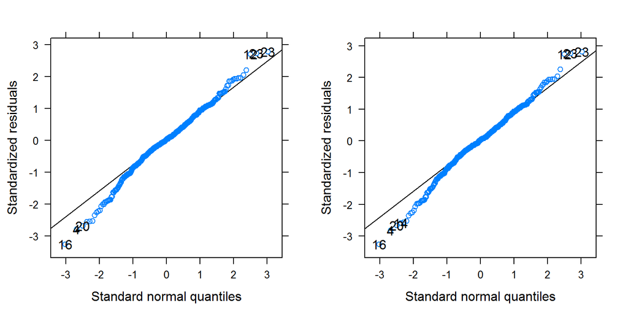

```r
qqp_m1 <- qqmath(m_fp_spill_al_1$full_model, id = 0.01, idLabels = as.character(drp_r$P.s))
qqp_m2 <- qqmath(m_fp_spill_al_3$full_model, id = 0.01, idLabels = as.character(drp_r$P.s))
grid.arrange(qqp_m1, qqp_m2, ncol = 2)
```

The effect of `log_acc` is not significant.

```r
nice(m_fp_spill_al_1)
```

```
## Mixed Model Anova Table (Type 3 tests, KR-method)
##
## Model: log_spill ~ log_acc + (log_acc | P.s) + (Fit | Item)
## Data: drp_r
##    Effect       df    F p.value
## 1 log_acc 1, 12.34 0.33     .57
## ---
## Signif. codes:  0 '***' 0.001 '**' 0.01 '*' 0.05 '+' 0.1 ' ' 1
```

```r
nice(m_fp_spill_al_3)
```

```
## Mixed Model Anova Table (Type 3 tests, KR-method)
##
## Model: log_spill ~ log_acc + (log_acc || P.s) + (1 | Item)
## Data: drp_r
##    Effect        df    F p.value
## 1 log_acc 1, 241.58 0.29     .59
## ---
## Signif. codes:  0 '***' 0.001 '**' 0.01 '*' 0.05 '+' 0.1 ' ' 1
```

### With Accepts (log-transformed RTs)

```r
m_fp_spill_a_1 <- mixed(log_spill ~ acc_z + (acc_z|P.s) + (Fit| Item), drp_r, progress = FALSE)
```

```
## Contrasts set to contr.sum for the following variables: P.s, Fit, Item
```

```r
summary(m_fp_spill_a_1)
```

```
## Linear mixed model fit by REML ['merModLmerTest']
## Formula: log_spill ~ acc_z + (acc_z | P.s) + (Fit | Item)
##    Data: drp_r
##
## REML criterion at convergence: 345
##
## Scaled residuals:
##     Min      1Q  Median      3Q     Max
## -3.2609 -0.5022  0.0421  0.5950  2.7932
##
## Random effects:
##  Groups   Name        Variance  Std.Dev. Corr
##  P.s      (Intercept) 5.866e-02 0.242188
##           acc_z       1.125e-04 0.010608 -1.00
##  Item     (Intercept) 4.181e-02 0.204471
##           Fit1        6.807e-06 0.002609 1.00
##  Residual             1.066e-01 0.326562
## Number of obs: 406, groups:  P.s, 24; Item, 17
##
## Fixed effects:
##             Estimate Std. Error t value
## (Intercept)  0.72727    0.07187  10.120
## acc_z       -0.01019    0.01967  -0.518
##
## Correlation of Fixed Effects:
##       (Intr)
## acc_z -0.053
```

Again we observe large correlations between the by-participant and by-item random-effects parameters and we refit the model without these correlations.

```r
m_fp_spill_a_2 <- mixed(log_spill ~ acc_z + (acc_z||P.s) + (Fit||Item), drp_r, expand_re = TRUE, progress = FALSE)
```

```
## Contrasts set to contr.sum for the following variables: P.s, Fit, Item
```

```r
summary(m_fp_spill_a_2)
```

```
## Linear mixed model fit by REML ['merModLmerTest']
## Formula: log_spill ~ acc_z + ((1 | P.s) + (0 + re1.acc_z | P.s)) + ((1 |
##     Item) + (0 + re2.Fit1 | Item))
##    Data: drp_r
##
## REML criterion at convergence: 345.3
##
## Scaled residuals:
##     Min      1Q  Median      3Q     Max
## -3.2545 -0.5085  0.0326  0.5899  2.8307
##
## Random effects:
##  Groups   Name        Variance Std.Dev.
##  P.s      (Intercept) 0.05870  0.2423
##  P.s.1    re1.acc_z   0.00000  0.0000
##  Item     (Intercept) 0.04155  0.2038
##  Item.1   re2.Fit1    0.00000  0.0000
##  Residual             0.10678  0.3268
## Number of obs: 406, groups:  P.s, 24; Item, 17
##
## Fixed effects:
##              Estimate Std. Error t value
## (Intercept)  0.727808   0.071787  10.138
## acc_z       -0.009149   0.019556  -0.468
##
## Correlation of Fixed Effects:
##       (Intr)
## acc_z 0.000
```

And the by-item random slope is now estimated at zero, we consequently refit the model without this parameters.

```r
m_fp_spill_a_3 <- mixed(log_spill ~ acc_z + (1|P.s) + (1| Item), drp_r, expand_re = TRUE, progress = FALSE)
```

```
## Contrasts set to contr.sum for the following variables: P.s, Item
```

```r
summary(m_fp_spill_a_3)
```

```
## Linear mixed model fit by REML ['merModLmerTest']
## Formula: log_spill ~ acc_z + (1 | P.s) + (1 | Item)
##    Data: drp_r
##
## REML criterion at convergence: 345.3
##
## Scaled residuals:
##     Min      1Q  Median      3Q     Max
## -3.2545 -0.5085  0.0326  0.5899  2.8307
##
## Random effects:
##  Groups   Name        Variance Std.Dev.
##  P.s      (Intercept) 0.05870  0.2423
##  Item     (Intercept) 0.04155  0.2038
##  Residual             0.10678  0.3268
## Number of obs: 406, groups:  P.s, 24; Item, 17
##
## Fixed effects:
##              Estimate Std. Error t value
## (Intercept)  0.727808   0.071787  10.138
## acc_z       -0.009149   0.019556  -0.468
##
## Correlation of Fixed Effects:
##       (Intr)
## acc_z 0.000
```

This model seems reasonable and only provides basically the same account as the first model.

```r
anova(m_fp_spill_a_1, m_fp_spill_a_3)
```

```
## Data: drp_r
## Models:
## m_fp_spill_a_3: log_spill ~ acc_z + (1 | P.s) + (1 | Item)
## m_fp_spill_a_1: log_spill ~ acc_z + (acc_z | P.s) + (Fit | Item)
##                Df    AIC    BIC  logLik deviance  Chisq Chi Df Pr(>Chisq)
## m_fp_spill_a_3  5 355.35 375.38 -172.68   345.35
## m_fp_spill_a_1  9 362.97 399.03 -172.49   344.97 0.3778      4     0.9843
```

The QQ-plot of both models again shows considerable departarue from normality for small RTs.

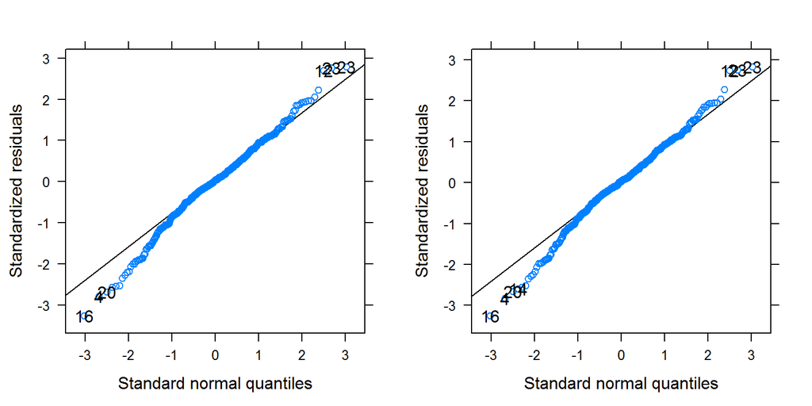

```r
qqp_m1 <- qqmath(m_fp_spill_a_1$full_model, id = 0.01, idLabels = as.character(drp_r$P.s))
qqp_m2 <- qqmath(m_fp_spill_a_3$full_model, id = 0.01, idLabels = as.character(drp_r$P.s))
grid.arrange(qqp_m1, qqp_m2, ncol = 2)
```

The effect of `acc_z` is not significant.

```r
nice(m_fp_spill_a_1)
```

```
## Mixed Model Anova Table (Type 3 tests, KR-method)
##
## Model: log_spill ~ acc_z + (acc_z | P.s) + (Fit | Item)
## Data: drp_r
##   Effect       df    F p.value
## 1  acc_z 1, 12.30 0.25     .63
## ---
## Signif. codes:  0 '***' 0.001 '**' 0.01 '*' 0.05 '+' 0.1 ' ' 1
```

```r
nice(m_fp_spill_a_3)
```

```
## Mixed Model Anova Table (Type 3 tests, KR-method)
##
## Model: log_spill ~ acc_z + (1 | P.s) + (1 | Item)
## Data: drp_r
##   Effect        df    F p.value
## 1  acc_z 1, 380.81 0.22     .64
## ---
## Signif. codes:  0 '***' 0.001 '**' 0.01 '*' 0.05 '+' 0.1 ' ' 1
```

## With Accept (reduced data set)

Finally we again use the reduced data set.

```r
m_fp_spill_lambert_a_1 <- mixed(log_spill ~ acc_z + (acc_z|P.s) + (Fit| Item), drp_r_r2, progress = FALSE)
```

```
## Contrasts set to contr.sum for the following variables: P.s, Fit, Item
```

```
## Numerical variables NOT centered on 0 (i.e., interpretation of all main effects might be difficult if in interactions): acc_z
```

```r
summary(m_fp_spill_lambert_a_1)
```

```
## Linear mixed model fit by REML ['merModLmerTest']
## Formula: log_spill ~ acc_z + (acc_z | P.s) + (Fit | Item)
##    Data: drp_r_r2
##
## REML criterion at convergence: 333.4
##
## Scaled residuals:
##      Min       1Q   Median       3Q      Max
## -2.80655 -0.49986  0.02843  0.58778  2.84273
##
## Random effects:
##  Groups   Name        Variance  Std.Dev. Corr
##  P.s      (Intercept) 6.066e-02 0.246297
##           acc_z       9.725e-05 0.009862 -1.00
##  Item     (Intercept) 4.040e-02 0.201005
##           Fit1        3.787e-05 0.006154 1.00
##  Residual             1.035e-01 0.321670
## Number of obs: 405, groups:  P.s, 24; Item, 17
##
## Fixed effects:
##             Estimate Std. Error t value
## (Intercept)  0.72968    0.07179  10.165
## acc_z       -0.01322    0.01943  -0.681
##
## Correlation of Fixed Effects:
##       (Intr)
## acc_z -0.021
```

We again remove the correlations.

```r
m_fp_spill_lambert_a_2 <- mixed(log_spill ~ acc_z + (acc_z||P.s) + (Fit || Item), drp_r_r2, progress = FALSE, expand_re = TRUE)
```

```
## Contrasts set to contr.sum for the following variables: P.s, Fit, Item
```

```
## Numerical variables NOT centered on 0 (i.e., interpretation of all main effects might be difficult if in interactions): acc_z
```

```r
summary(m_fp_spill_lambert_a_2)
```

```
## Linear mixed model fit by REML ['merModLmerTest']
## Formula: log_spill ~ acc_z + ((1 | P.s) + (0 + re1.acc_z | P.s)) + ((1 |
##     Item) + (0 + re2.Fit1 | Item))
##    Data: drp_r_r2
##
## REML criterion at convergence: 333.8
##
## Scaled residuals:
##      Min       1Q   Median       3Q      Max
## -2.85657 -0.50710  0.01931  0.57622  2.86342
##
## Random effects:
##  Groups   Name        Variance Std.Dev.
##  P.s      (Intercept) 0.06076  0.2465
##  P.s.1    re1.acc_z   0.00000  0.0000
##  Item     (Intercept) 0.04016  0.2004
##  Item.1   re2.Fit1    0.00000  0.0000
##  Residual             0.10362  0.3219
## Number of obs: 405, groups:  P.s, 24; Item, 17
##
## Fixed effects:
##             Estimate Std. Error t value
## (Intercept)  0.73066    0.07176  10.181
## acc_z       -0.01170    0.01928  -0.607
##
## Correlation of Fixed Effects:
##       (Intr)
## acc_z 0.000
```

Now the random slopes are estimated to be virtually zero, we consequently refit the model without this parameter.

```r
m_fp_spill_lambert_a_3 <- mixed(log_spill ~ acc_z + (1|P.s) + (1| Item), drp_r_r2, progress = FALSE, expand_re = TRUE)
```

```
## Contrasts set to contr.sum for the following variables: P.s, Item
```

```
## Numerical variables NOT centered on 0 (i.e., interpretation of all main effects might be difficult if in interactions): acc_z
```

```r
summary(m_fp_spill_lambert_a_3)
```

```
## Linear mixed model fit by REML ['merModLmerTest']
## Formula: log_spill ~ acc_z + (1 | P.s) + (1 | Item)
##    Data: drp_r_r2
##
## REML criterion at convergence: 333.8
##
## Scaled residuals:
##      Min       1Q   Median       3Q      Max
## -2.85657 -0.50710  0.01931  0.57622  2.86342
##
## Random effects:
##  Groups   Name        Variance Std.Dev.
##  P.s      (Intercept) 0.06076  0.2465
##  Item     (Intercept) 0.04016  0.2004
##  Residual             0.10362  0.3219
## Number of obs: 405, groups:  P.s, 24; Item, 17
##
## Fixed effects:
##             Estimate Std. Error t value
## (Intercept)  0.73066    0.07176  10.181
## acc_z       -0.01170    0.01928  -0.607
##
## Correlation of Fixed Effects:
##       (Intr)
## acc_z 0.000
```

Again the final model appears to be the optimal model.

```r
anova(m_fp_spill_lambert_a_1, m_fp_spill_lambert_a_2, m_fp_spill_lambert_a_3)
```

```
## Data: drp_r_r2
## Models:
## m_fp_spill_lambert_a_3: log_spill ~ acc_z + (1 | P.s) + (1 | Item)
## m_fp_spill_lambert_a_2: log_spill ~ acc_z + ((1 | P.s) + (0 + re1.acc_z | P.s)) + ((1 |
## m_fp_spill_lambert_a_2:     Item) + (0 + re2.Fit1 | Item))
## m_fp_spill_lambert_a_1: log_spill ~ acc_z + (acc_z | P.s) + (Fit | Item)
##                        Df    AIC    BIC  logLik deviance  Chisq Chi Df
## m_fp_spill_lambert_a_3  5 343.83 363.85 -166.92   333.83
## m_fp_spill_lambert_a_2  7 347.83 375.86 -166.92   333.83 0.0000      2
## m_fp_spill_lambert_a_1  9 351.39 387.43 -166.70   333.39 0.4398      2
##                        Pr(>Chisq)
## m_fp_spill_lambert_a_3
## m_fp_spill_lambert_a_2     1.0000
## m_fp_spill_lambert_a_1     0.8026
```

The QQ-plot now still shows violations at the edges.

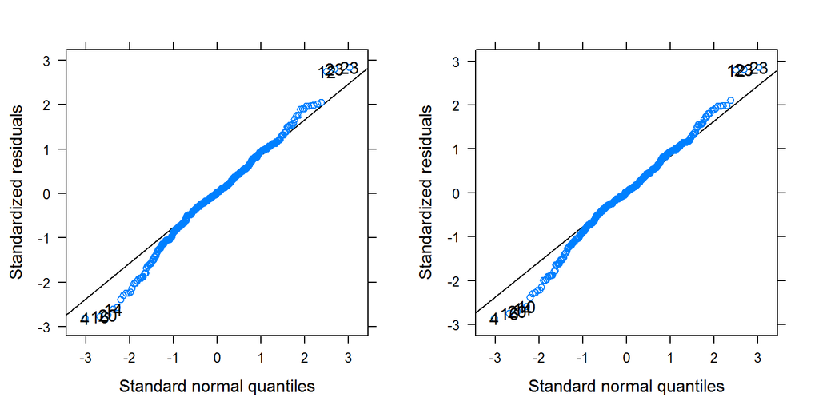

```r
qqp_m1 <- qqmath(m_fp_spill_lambert_a_1$full_model, id = 0.01, idLabels = as.character(drp_r_r2$P.s))
qqp_m2 <- qqmath(m_fp_spill_lambert_a_3$full_model, id = 0.01, idLabels = as.character(drp_r_r2$P.s))
grid.arrange(qqp_m1, qqp_m2, ncol = 2)
```

```r
nice(m_fp_spill_lambert_a_1)
```

```
## Mixed Model Anova Table (Type 3 tests, KR-method)
##
## Model: log_spill ~ acc_z + (acc_z | P.s) + (Fit | Item)
## Data: drp_r_r2
##   Effect       df    F p.value
## 1  acc_z 1, 12.33 0.43     .52
## ---
## Signif. codes:  0 '***' 0.001 '**' 0.01 '*' 0.05 '+' 0.1 ' ' 1
```

```r
nice(m_fp_spill_lambert_a_3)
```

```
## Mixed Model Anova Table (Type 3 tests, KR-method)
##
## Model: log_spill ~ acc_z + (1 | P.s) + (1 | Item)
## Data: drp_r_r2
##   Effect        df    F p.value
## 1  acc_z 1, 379.73 0.36     .55
## ---
## Signif. codes:  0 '***' 0.001 '**' 0.01 '*' 0.05 '+' 0.1 ' ' 1
```